# Machine Learning Course Project

Moises Egues

7 de agosto de 2016

## Executive Summary

This project uses data from accelerometers on the belt, forearm, arm, and dumbell of 6 participants. They were asked to perform barbell lifts correctly and incorrectly in 5 different ways. The goal of this project is to predict the manner in which they did the exercise and also uses this prediction model to predict 20 different test cases.

## Data Loading

Loading required packages:

```r
library(caret); library(rpart); library(rattle);
library(rpart.plot); library(repmis); library(randomForest);
```

```r
trainingData <- read.csv("pml-training.csv", na.strings = c("NA", ""))
testingData <- read.csv("pml-testing.csv", na.strings = c("NA", ""))
dim(trainingData)
```

```
## [1] 19622   160
```

```r
dim(testingData)
```

```
## [1]  20 160
```

The variable used in the prediction model is **classe** in the training set.

## Cleaning the data

In the prediction analysis will use only the predictors that has no missing values. Also, the first seven predictors were removed because have little predicting power for the outcome classe.

```r
trainingData <- trainingData[, colSums(is.na(trainingData)) == 0]
testingData <- testingData[, colSums(is.na(testingData)) == 0]

trainingData <- trainingData[, -c(1:7)]
testingData <- testingData[, -c(1:7)]
```

## Data Partitioning

The cleaned training data will be partitioned into a training set (70%) for prediction and a validation set (30%) to get the out-of-sample errors.

```r
set.seed(4758)
indexTraining <- createDataPartition(trainingData$classe, p = 0.7, list = FALSE)
training <- trainingData[indexTraining, ]
validation <- trainingData[-indexTraining, ]
```

## Prediction Analysis

In our analysis we use classification trees and random forests to predict the outcome of the variable **classe**.

### Classification trees

We use K=5 for cross validation because we do not transform any variable and will save some computing time.

```r
control <- trainControl(method = "cv", number = 5)
fit_classTree <- train(classe ~ ., data = training, method = "rpart",
                   trControl = control)
print(fit_classTree, digits = 4)
```

```
## CART
##
## 13737 samples
##    52 predictor
##     5 classes: 'A', 'B', 'C', 'D', 'E'
##
## No pre-processing
## Resampling: Cross-Validated (5 fold)
## Summary of sample sizes: 10989, 10989, 10990, 10990, 10990
## Resampling results across tuning parameters:
##
##   cp       Accuracy  Kappa
##   0.03347  0.5187    0.3719
##   0.05981  0.4674    0.2947
##   0.11515  0.3157    0.0478
##
## Accuracy was used to select the optimal model using  the largest value.
## The final value used for the model was cp = 0.03347.
```

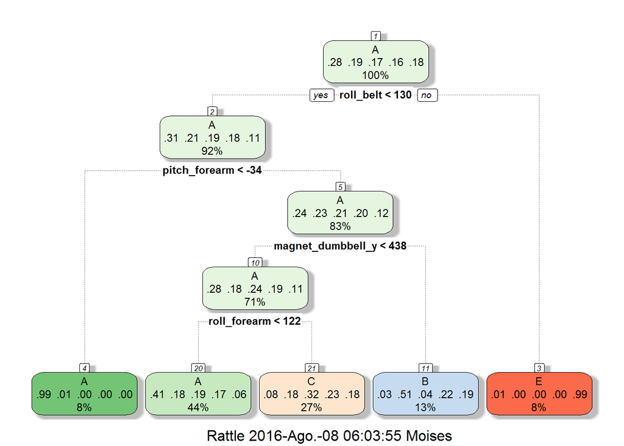

```r
fancyRpartPlot(fit_classTree$finalModel)
```

```r
# Apply the predict model using validation set to get the outcomes
predict_classTree <- predict(fit_classTree, validation)

# Show prediction result
(conf_classTree <- confusionMatrix(validation$classe, predict_classTree))
```

```
## Confusion Matrix and Statistics
##
##           Reference
## Prediction    A    B    C    D    E
##          A 1511   30  130    0    3
##          B  478  391  270    0    0
##          C  466   34  526    0    0
##          D  428  181  355    0    0
##          E  155  147  292    0  488
##
## Overall Statistics
##
##                Accuracy : 0.4955
##                  95% CI : (0.4826, 0.5084)
##     No Information Rate : 0.5162
##     P-Value [Acc > NIR] : 0.9993
##
##                   Kappa : 0.3409
##  Mcnemar's Test P-Value : NA
##
## Statistics by Class:
##
##                      Class: A Class: B Class: C Class: D Class: E
## Sensitivity            0.4974  0.49936  0.33439       NA  0.99389
## Specificity            0.9427  0.85339  0.88404   0.8362  0.88988
## Pos Pred Value         0.9026  0.34328  0.51267       NA  0.45102
## Neg Pred Value         0.6374  0.91740  0.78452       NA  0.99938
## Prevalence             0.5162  0.13305  0.26729   0.0000  0.08343
## Detection Rate         0.2568  0.06644  0.08938   0.0000  0.08292
## Detection Prevalence   0.2845  0.19354  0.17434   0.1638  0.18386
## Balanced Accuracy      0.7201  0.67638  0.60922       NA  0.94188
```

```r
(accuracy_classTree <- conf_classTree$overall[1])
```

```
## Accuracy
## 0.495497
```

Review the confusion matrix, we get an accuracy rate = 0.495, and so the out-of-sample error rate is 0.5. Then, this prediction model based on classification tree does not predict the outcome classe very well.

### Random forests

We continue the prediction analysis trying the random forest method:

```r
fit_randForests <- train(classe ~ ., data = training, method = "rf",
                   trControl = control)
print(fit_randForests, digits = 4)
```

```
## Random Forest
##
## 13737 samples
##    52 predictor
##     5 classes: 'A', 'B', 'C', 'D', 'E'
##
## No pre-processing
## Resampling: Cross-Validated (5 fold)
## Summary of sample sizes: 10990, 10988, 10989, 10991, 10990
## Resampling results across tuning parameters:
##
##   mtry  Accuracy  Kappa
##    2    0.9900    0.9873
##   27    0.9899    0.9872
##   52    0.9836    0.9793
##
## Accuracy was used to select the optimal model using  the largest value.
## The final value used for the model was mtry = 2.
```

```r
# Apply the predict model using validation set to get the outcomes
predict_randForests <- predict(fit_randForests, validation)

# Show prediction result
(conf_randForests <- confusionMatrix(validation$classe, predict_randForests))
```

```
## Confusion Matrix and Statistics
##
##           Reference
## Prediction    A    B    C    D    E
##          A 1672    2    0    0    0
##          B    4 1134    1    0    0
##          C    0    7 1018    1    0
##          D    0    0   15  949    0
##          E    0    0    0    7 1075
##
## Overall Statistics
##
##                Accuracy : 0.9937
##                  95% CI : (0.9913, 0.9956)
##     No Information Rate : 0.2848
##     P-Value [Acc > NIR] : < 2.2e-16
##
##                   Kappa : 0.992
##  Mcnemar's Test P-Value : NA
##
## Statistics by Class:
##
##                      Class: A Class: B Class: C Class: D Class: E
## Sensitivity            0.9976   0.9921   0.9845   0.9916   1.0000
## Specificity            0.9995   0.9989   0.9984   0.9970   0.9985
## Pos Pred Value         0.9988   0.9956   0.9922   0.9844   0.9935
## Neg Pred Value         0.9991   0.9981   0.9967   0.9984   1.0000
## Prevalence             0.2848   0.1942   0.1757   0.1626   0.1827
## Detection Rate         0.2841   0.1927   0.1730   0.1613   0.1827
## Detection Prevalence   0.2845   0.1935   0.1743   0.1638   0.1839
## Balanced Accuracy      0.9986   0.9955   0.9914   0.9943   0.9993
```

```r
(accuracy_randForests <- conf_randForests$overall[1])
```

```
##  Accuracy
## 0.9937128
```

## Testing the prediction model

Finally, the prediction model based on random forests will be used to predict the outcome variable classe for the testing data set:

```r
(predict(fit_randForests, testingData))
```

```
##  [1] B A B A A E D B A A B C B A E E A B B B
## Levels: A B C D E
```